# W3S2

Hussain Alsalman

5/19/2019

## What We learned so far?

- The difference between supervised learning vs unsupervised learning
- The concept of linear regression model ?
- Constructing regression models with R.
- Interperting your model

## What you will learn tonight

- The concept of logistic regression
- The concept of regularization and shrinkage

## Introduction to Logistic Regression

Not all data can be appropriately modeled with linear regression, because they are **binomial** (TRUE/FALSE), count data or some other form. To model these types of data, we use different type linear models. Logestic Regression is one of them.

## We can’t we just use the simple regression line.

Consider this example

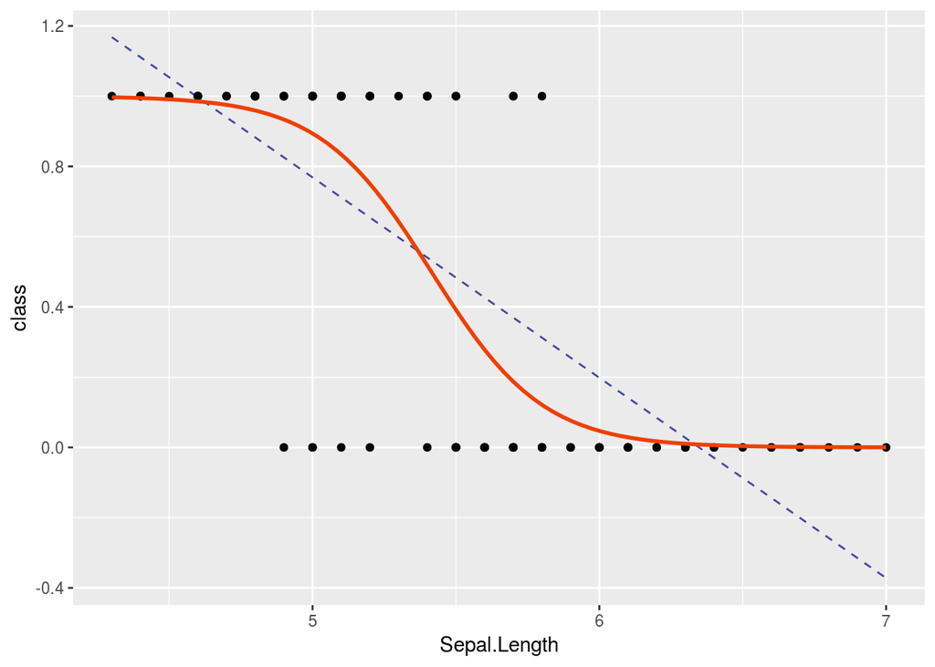

```r
#Why can't we just do regression model .. what can go wrong?
iris[1:100,] %>%  mutate( class = ifelse(Species == "setosa",1,0)) %>%
ggplot(mapping = aes(x = Sepal.Length, y = class, group  =1)) +
  geom_point() +
  stat_smooth(geom = "line",method= "lm", se = FALSE,alpha = 0.7, color = "navy",linetype = "dashed") +

  #or we can alternatively use more flexible line
  geom_smooth(method = "glm", method.args = list(family = "binomial"), se = FALSE, color="orangered2")
```

## Logestic Regression Models

One of the most powerfull tools to answer yes/no questions (*binary classificaiton*) is logestic regression.

remember this equaiton ?

$$y = \beta_{0} + \beta_{1}x_{1} + \beta_{2}x_{2} + \dots + \beta_{n}x_{n} + \epsilon$$

we will make few modifications to make the output from 0 to 1. This modification is called **logit transofrmation**.

The final function will look something like this

$$\pi(x) = \frac{e^{\beta_{0} + \beta_{1}x_{1} + \beta_{2}x_{2} + \dots + \beta_{n}x_{n}}}{1 + e^{\beta_{0} + \beta_{1}x_{1} + \beta_{2}x_{2} + \dots + \beta_{n}x_{n}}}$$

## Let’s work by Example

Here we have data for the households in New York State.

### Can we Answer this question :

Can we classify whether a household has an income greater than $150,000 or not?

```r
acs <- read.table("http://jaredlander.com/data/acs_ny.csv", sep=",", header=TRUE, stringsAsFactors=FALSE)
```

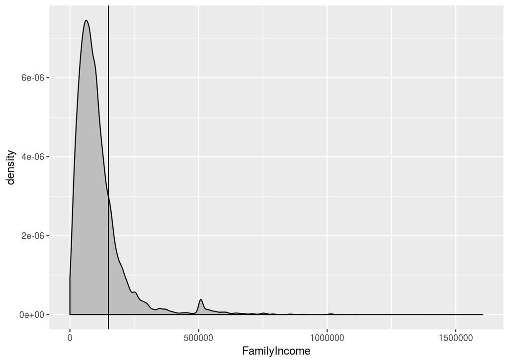

```r
# first thing we do is engineer a categorical variable for income
library("dplyr")
library("tidyverse")

acs <- acs %>% mutate( Income = FamilyIncome >= 150000)

## Let's see visualize the income to get and idea about the distribution

## to visualize how thie distribution income in the data
library("ggplot2")
ggplot(acs, mapping = aes(x = FamilyIncome)) +
  geom_density(fill = "gray")   +
  geom_vline(xintercept = 150000)
```

```r
## We can now create our model simply but calling the glm function. `glm` stands for gereralized linear models.

incom1 <- glm( Income ~ HouseCosts + NumWorkers + OwnRent + NumBedrooms + FamilyType, data = acs, family = "binomial")

summary(incom1)
```

```
##
## Call:
## glm(formula = Income ~ HouseCosts + NumWorkers + OwnRent + NumBedrooms +
##     FamilyType, family = "binomial", data = acs)
##
## Deviance Residuals:
##     Min       1Q   Median       3Q      Max
## -2.8452  -0.6246  -0.4231  -0.1743   2.9503
##
## Coefficients:
##                       Estimate Std. Error z value Pr(>|z|)
## (Intercept)         -5.738e+00  1.185e-01 -48.421   <2e-16 ***
## HouseCosts           7.398e-04  1.724e-05  42.908   <2e-16 ***
## NumWorkers           5.611e-01  2.588e-02  21.684   <2e-16 ***
## OwnRentOutright      1.772e+00  2.075e-01   8.541   <2e-16 ***
## OwnRentRented       -8.886e-01  1.002e-01  -8.872   <2e-16 ***
## NumBedrooms          2.339e-01  1.683e-02  13.895   <2e-16 ***
## FamilyTypeMale Head  3.336e-01  1.472e-01   2.266   0.0235 *
## FamilyTypeMarried    1.405e+00  8.704e-02  16.143   <2e-16 ***
## ---
## Signif. codes:  0 '***' 0.001 '**' 0.01 '*' 0.05 '.' 0.1 ' ' 1
##
## (Dispersion parameter for binomial family taken to be 1)
##
##     Null deviance: 22808  on 22744  degrees of freedom
## Residual deviance: 18073  on 22737  degrees of freedom
## AIC: 18089
##
## Number of Fisher Scoring iterations: 6
```

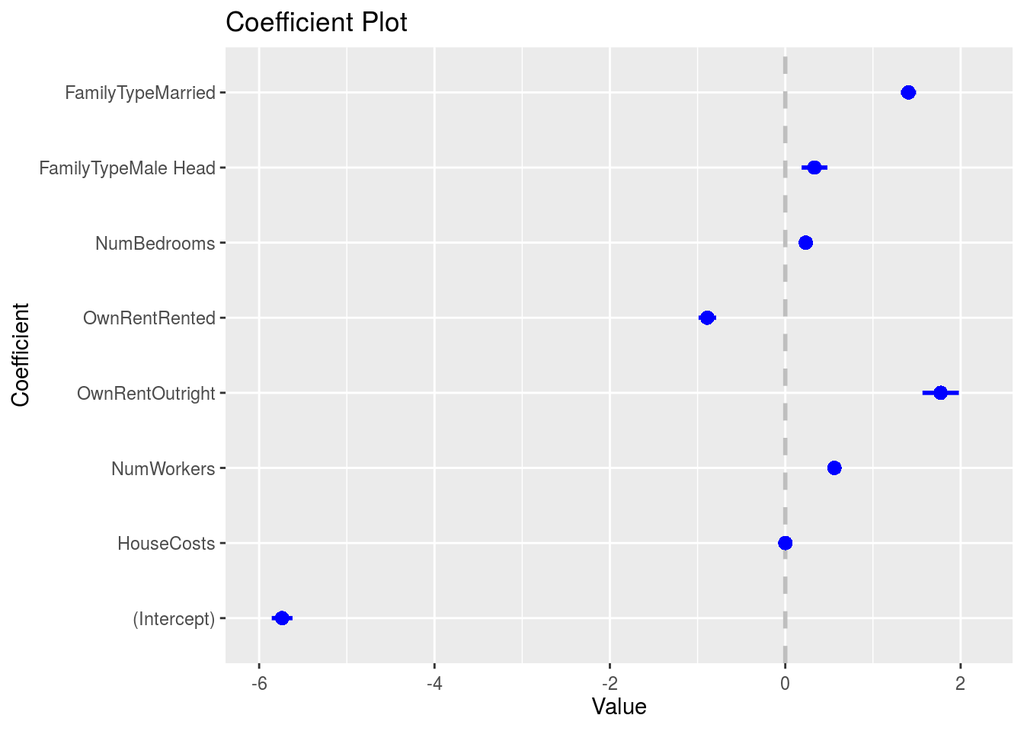

```r
# we read the coefficients as weights and gain insight on about the relationship between independant variables and the depandent variable.
## We can examine our betas if they are significant

library("coefplot")

coefplot(incom1)
```

## How to select the variables for our regression model

Our objective is to come up with a simple and powerful regression model. This model should have these two characteristics

- Select only the important variables
- Have stable weights _ coefficients_

$$\hat{y} = \hat\beta_{0} + \hat\beta_{1}x_{1} + \hat\beta_{2}x_{2} + \dots + \hat\beta_{n}x_{n}$$

Remember that our objective is to minimize the sum of squared error **SSE**.

$$\sum_{i=1}^{n}(y_{i} - \hat{y}_i)^2$$

We can add a penelty in the formula above for using too many variables. This is called **lasso regression**. This penelty is also called **regularization**.

We can also add another panelty for using big Betas. This is called **ridge regression**. It is also called **shrinkage**.

combining them together is called **Elastic Net**.

The equation in the most simple and silly way would look like this

$$min(error) = SSE + panelty$$

## Math check !!

Remember this equation. This is the same equation we have been seening all the time tonight but in different form.

$$\begin{bmatrix}
y_{1} \\ y_{2} \\ \dots \\ y_{n}
\end{bmatrix} =
\begin{bmatrix}
1 & x_{12} & x_{13} & \dots & x_{1n} \\
1 & x_{22} & x_{23} & \dots & x_{2n} \\
\dots & \dots & \dots & \dots & \dots \\
1 & x_{n2} & x_{n3} & \dots & x_{nn}
\end{bmatrix}
\begin{bmatrix}
\beta_0 \\ \beta_1 \\ \dots \\ \beta_{n}
\end{bmatrix}$$

The short form of this formula is

$$Y = X\beta$$

Understanding this is important to go to the next step

```r
testFrame <-
 data.frame(First=sample(1:10, 20, replace=TRUE),
 Second=sample(1:20, 20, replace=TRUE),
 Third=sample(1:10, 20, replace=TRUE),
 Fourth=factor(rep(c("Alice", "Bob", "Charlie", "David"), 5)),
 Fifth=ordered(rep(c("Edward", "Frank", "Georgia",
 "Hank", "Isaac"), 4)),
 Sixth=rep(c("a", "b"), 10), stringsAsFactors=F)

str(testFrame)
```

```
## 'data.frame':    20 obs. of  6 variables:
##  $ First : int  8 4 6 4 9 2 4 4 8 5 ...
##  $ Second: int  11 3 6 5 5 7 11 14 8 1 ...
##  $ Third : int  2 10 3 9 3 7 10 5 9 8 ...
##  $ Fourth: Factor w/ 4 levels "Alice","Bob",..: 1 2 3 4 1 2 3 4 1 2 ...
##  $ Fifth : Ord.factor w/ 5 levels "Edward"<"Frank"<..: 1 2 3 4 5 1 2 3 4 5 ...
##  $ Sixth : chr  "a" "b" "a" "b" ...
```

```r
head(testFrame)
```

```
##   First Second Third  Fourth   Fifth Sixth
## 1     8     11     2   Alice  Edward     a
## 2     4      3    10     Bob   Frank     b
## 3     6      6     3 Charlie Georgia     a
## 4     4      5     9   David    Hank     b
## 5     9      5     3   Alice   Isaac     a
## 6     2      7     7     Bob  Edward     b
```

Let’s design the X matrix. I hope you still remember how we encode the *categorical variables* :)

```r
head(model.matrix(First ~ Second + Fourth + Fifth, testFrame))
```

```
##   (Intercept) Second FourthBob FourthCharlie FourthDavid    Fifth.L
## 1           1     11         0             0           0 -0.6324555
## 2           1      3         1             0           0 -0.3162278
## 3           1      6         0             1           0  0.0000000
## 4           1      5         0             0           1  0.3162278
## 5           1      5         0             0           0  0.6324555
## 6           1      7         1             0           0 -0.6324555
##      Fifth.Q       Fifth.C    Fifth^4
## 1  0.5345225 -3.162278e-01  0.1195229
## 2 -0.2672612  6.324555e-01 -0.4780914
## 3 -0.5345225 -4.095972e-16  0.7171372
## 4 -0.2672612 -6.324555e-01 -0.4780914
## 5  0.5345225  3.162278e-01  0.1195229
## 6  0.5345225 -3.162278e-01  0.1195229
```

Notice that the `model.matrix` has converted the categorical variables to dummy variables. This is different with the `Fifth` column as this is an ordinal variable.

for our purposes we need all variables as flags either *On* or *Off* . so we design it with modificaiton as the following

```r
#we will use the build.x form 'useful' package

head(build.x(First ~ Second + Fourth + Fifth, testFrame, contrasts = FALSE))
```

```
##   (Intercept) Second FourthAlice FourthBob FourthCharlie FourthDavid
## 1           1     11           1         0             0           0
## 2           1      3           0         1             0           0
## 3           1      6           0         0             1           0
## 4           1      5           0         0             0           1
## 5           1      5           1         0             0           0
## 6           1      7           0         1             0           0
##   FifthEdward FifthFrank FifthGeorgia FifthHank FifthIsaac
## 1           1          0            0         0          0
## 2           0          1            0         0          0
## 3           0          0            1         0          0
## 4           0          0            0         1          0
## 5           0          0            0         0          1
## 6           1          0            0         0          0
```

```r
# we can remove the intercept by adding -1

head(build.x(First ~ Second + Fourth + Fifth -1, testFrame, contrasts = FALSE))
```

```
##   Second FourthAlice FourthBob FourthCharlie FourthDavid FifthEdward
## 1     11           1         0             0           0           1
## 2      3           0         1             0           0           0
## 3      6           0         0             1           0           0
## 4      5           0         0             0           1           0
## 5      5           1         0             0           0           0
## 6      7           0         1             0           0           1
##   FifthFrank FifthGeorgia FifthHank FifthIsaac
## 1          0            0         0          0
## 2          1            0         0          0
## 3          0            1         0          0
## 4          0            0         1          0
## 5          0            0         0          1
## 6          0            0         0          0
```

## Let’s go back to our house example.

We will use `glment` package which implement this nice idea of panalizing the regression model.

```r
#first we create the Design matrix X
# do not include the intercept as glmnet will add that automatically
formula_m <- Income ~ NumBedrooms + NumChildren + NumPeople + NumRooms + NumUnits + NumVehicles + NumWorkers + OwnRent + YearBuilt + ElectricBill + FoodStamp + HeatingFuel + Insurance + Language - 1

acx_X <- build.x(formula_m, data = acs, contrasts = FALSE, sparse = TRUE)

#first we create the response matrix Y
# do not include the intercept as glmnet will add that automatically
acy_Y <- build.y(formula_m,data = acs)


library("glmnet")
set.seed(1863561)

m1  <- glmnet(x = acx_X, y = acy_Y, family = "binomial")

##viewing the weights using different lambdas

View(as.matrix(m1$beta))
```

Remember lambda? it is our penelty factor .. We decide the mix between lasso & rigid panelties by specifying `alpha`. the default value is 1 which is Lasso panelty. We can change it to .4 for example. This will mean that 40% lasso and 60% rigid.

Since we have not specified lambda, the function makes 100 iterations with different lamdba as seen with `View(as.matrix(m1$beta))`

We can visualize the effect of choosing different lambda

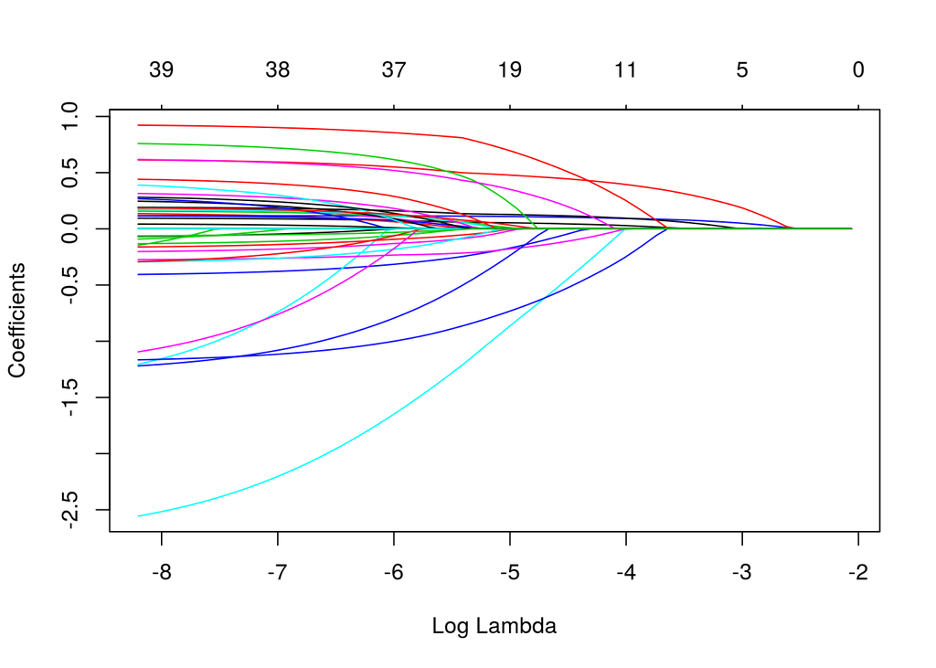

```r
plot(m1, xvar = "lambda")
```

```r
#We can see the effect of lambda interactively
coefpath(m1)
```

[interactive chart not shown]